# Exercise3_Schowing

## Exercise 3

## Simulations with two populations

Simulate coalescent trees with scrm for a structured population with two sub-populations, following the command lines provided below.

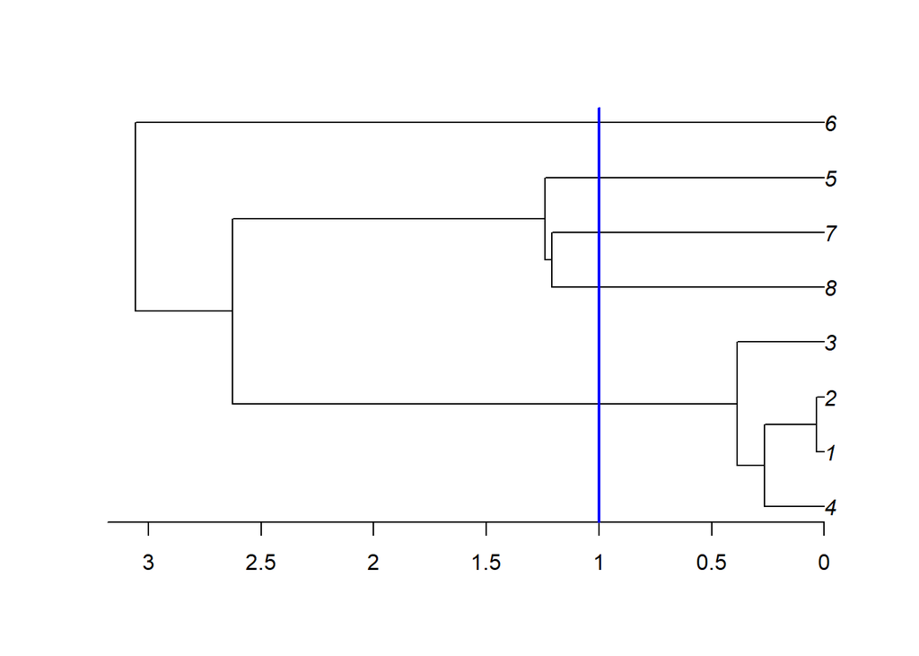

```r
# SIMULATE UNDER A MODEL WITH TWO POPULATIONS
# WHERE POP 1 has an N=1000
# POP2 and N2=10000
# AND THEY HAVE SPLIT WITHOUT MIGRATION T=4000 generations ago
# FROM AN ANCESTRAL POPULATION WITH SIZE N=2000
# with a sample size of 4 lineages from each population
library(scrm)
sum_stats <- scrm('8 10 -T -I 2 4 4 -n 1 1 -n 2 10 -ej 1 2 1 -en 1 1 2')

# NOTE: time is scaled in 4*N1 units!
# to get time in generations need to multiply by 4*N1

# read the trees with ape package read.tree function
library(ape)
trees <- read.tree(text = paste(sum_stats$trees[[1]], collapse = ""))

# plot the trees
plot(trees, no.margin = FALSE)
axisPhylo()

# Extract the coalescent intervals and TMRCA
coal_int <- coalescent.intervals(trees)
tmrca <- sum(coal_int$interval.length)

# Add line with the time of split
abline(v=tmrca-1, lwd=2, col=4)
```

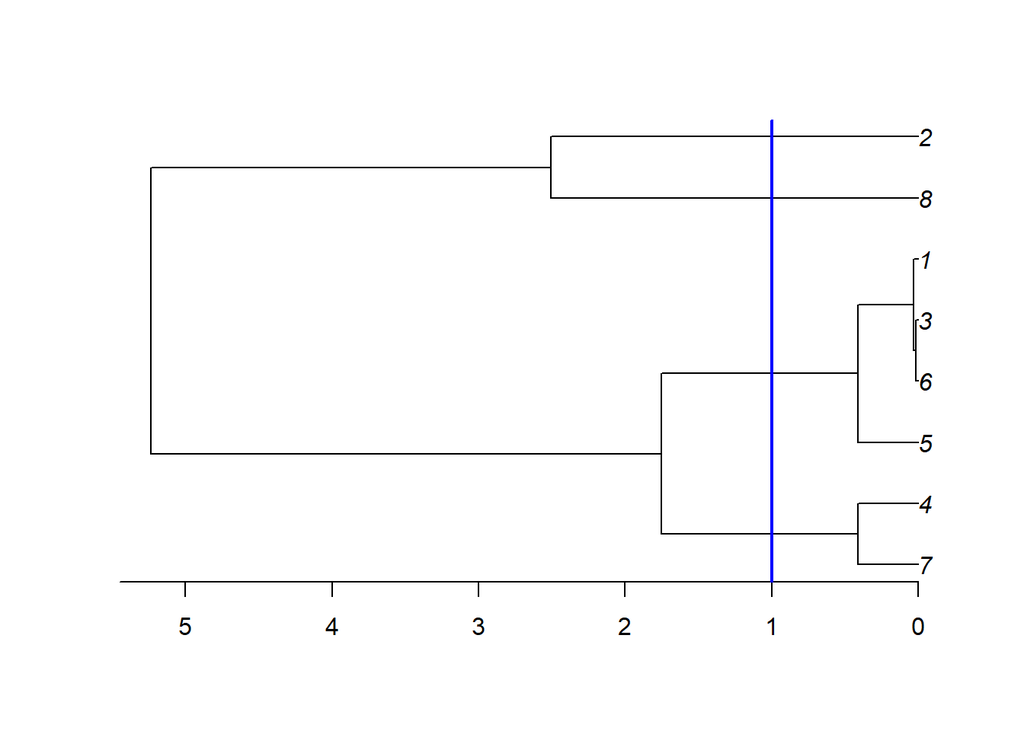

```r
# SIMULATE UNDER A MODEL WITH TWO POPULATIONS AND MIGRATION
# WHERE POP 1 has an N=1000
# POP2 and N2=10000
# AND THEY EXCHANGE GENES AT A RATE 4Nm=5.0
# AND THEY HAVE SPLIT T=4000 generations ago
# FROM AN ANCESTRAL POPULATION WITH SIZE N=2000
# with a sample size of 4 lineages from each population
sum_stats_mig <- scrm('8 10 -T -I 2 4 4 5.0 -n 1 1 -n 2 10 -ej 1 1 2 -eM 1 0  -en 1 1 2')

# NOTE: time is scaled in 4*N1 units!
# to get time in generations need to multiply by 4*N1

# read the trees with ape package read.tree function
library(ape)
trees <- read.tree(text = paste(sum_stats_mig$trees[[1]], collapse = ""))

# plot the trees
plot(trees, no.margin = FALSE)
axisPhylo()

# Extract the coalescent intervals and TMRCA
coal_int <- coalescent.intervals(trees)
tmrca <- sum(coal_int$interval.length)

# Add line with the time of split
abline(v=tmrca-1, lwd=2, col=4)
```

## TO DISCUSS

### Can we have coalescent events between lineages of the two populations even in the absence of gene flow?

After the split and without migration (gene flow) we can easily see the two population size. The small one (lineage 1, 2, 3 and 4) has much shorter branches after the split than the biggest one (5, 6, 7 and 8).

### What is the effect of adding migration to the gene trees? Can you detect migrant linages in the trees?

We can see that the lineage’s clusters are getting mixed. It is not possible to separate clearly the two population because a gene might have moved very soon from one lineage to another and even moved back.

### How does migration affect the patterns of diversity within and between populations?

Instead of having clearly distinguishable clusters (aka the two populations) with distinguishabl sizes, we have some lineages moving into the other cluster. With this process, the diversity present in the bigger population is added to the smaller one and vice versa. The branches length are what help to distinguish between the population.

big div coming from big pop

### Can you detect gene trees with ancestral polymorphism/incomplete lineage sorting?

As we can (hopefuly) differenciate the two populations by the length of the branches without migration, we can also see that the generated trees with migration have extrapolated the migrated individuals to the whole lineage, creating a lot of varying trees without a consistant structure (so, ILS).